# Language test scores

Dorothy Bishop

16/09/2017

## Language, literacy and neurocognitive assessments

We aim to combine twin data from this study with that from a previous study (Bishop, D. V. M., McDonald, D., Bird, S., & Hayiou-Thomas, M. E. 2009. Children who read accurately despite language impairment: Who are they and how do they do it? Child Development, 80, 593-605) and so the test battery overlaps substantially with the one used previously.

The battery had been selected with the goal of assessing expressive and receptive language, reading and nonverbal ability in a single test session lasting no longer than two hours. Tests were selected as being suitable for the age range under study with established norms, reliability and validity.

As noted below, although all tests had norms in the age range 6 to 12 years (corresponding to the twin sample), some tests lacked norms for older and/or younger children, some of whom were included in the sample with sex chromosome trisomies. We document below how we extrapolated norms for some tests.

(need to check manuals for reliability of all subtests).

1. **Verbal Comprehension** subtest from Woodcock Johnson III Tests of Cognitive Abilities (Woodcock, McGrew, & Mather, 2007)

In this test, up to six brightly coloured pictures of complex scenes are presented to the child. For each scene, the child responds to a series of commands presented from an audio file, such as ‘Point to the monkey before you point to the tallest tree’. A beep occurs after each command and the child is instructed not to respond before they hear the beep. No repetitions are allowed.

The test has a basal and ceiling, with recommended starting points based on age and ability, and stopping points determined by accuracy. Each item is scored 1 for a correct response and zero otherwise. Raw scores are converted to age-scaled scores with mean of 100 and SD of 15, using automated software provided by the test publisher.  
Need to check manual re age range, reliability, scaled scores

2. **Sentence Repetition** from NEPSY: A Developmental Neuropsychological Assessment (Korkman, Kirk, & Kemp, 1998)

The child repeats sentences spoken by the examiner, that increase in length and complexity as the test proceeds. There is a basal and ceiling, so the start point is determined by age, and testing stops after a given number of zero responses.

Items are scored 2 if fully correct verbatim recall, 1 if there are up to two errors, and 0 if more than 2 errors.

Norms are available for the age range 5;0 to 12;11 to convert raw scores to scaled scores with a mean of 10 and SD of 3. For older children, norms were extrapolated as described below.

3. **Repetition of Nonsense Words** from NEPSY The child repeats nonsense words heard over headphones from an audio tape. We recorded our own version of the nonsense words in a British accent - we have previously shown typically-developing children score within expected limits when tested on this version (need ref here!). There are 13 nonsense words that range in length from 2 to 5 syllables.

Scoring is according to number of syllables correct. The test was scored online, but also audio-recorded to allow the examiner to rescore if uncertain. Stable misarticulations and stress on the wrong syllable are not regarded as errors. All items are administered, but no further points are awarded after four consecutive scores of zero.(need to check we did that - can do so from raw scores on file).

Norms are available for the age range 5;0 to 12;11 to convert raw scores to scaled scores with a mean of 10 and SD of 3. For older children, norms were extrapolated as described below.

4. **Oromotor Sequences** from NEPSY

The test is introduced to the child by saying “Pretend you are a machine that makes a funny noise. The machine makes tin cans and goes ‘clonk clonk, clonk clonk’. Say that for me (pause for response). Now see how long you can make the machine’s sound. Keep going until I tell you to stop. Begin.”

The child is encouraged to continue until five sequences of ‘clonk clonk’ have been produced.

The first eight items are repeated nonsense sounds such as ‘clinkety clankety’. A further six items are tongue twister sentences such as ‘Sue said she should sell shoes.’

For each item, the child is encouraged to continue until five sequences have been produced. Speed is not emphasised. One point is awarded for each correct sequence.

In contrast to the other NEPSY subtests, the manual does not provide conversion to standard scores, but rather allows raw scores to be converted to an ordinal scale of five percentile ranges. For compatibility with the other subtests, and to allow for extension of norms to teenagers, we used normative data to derived standard scores with mean of 10 and SD of 3, as described below.

5. **Vocabulary** subtest from Wechsler Abbreviated Scale of Intelligence (WASI) (Wechsler, 1999)
6. **Block Design** subtest from WASI
7. **Matrices** subtest from WASI
8. **Picture Naming Test** from Phonological Assessment Battery (PhAB) (Frederickson, Frith, & Reason, 1997)
9. **Digit Naming Test** from PhAB
10. **Sight Word Efficiency** subtest from Test of Word Reading Efficiency (TOWRE) (Torgesen, Wagner, & Rashotte, 1999)
11. **Phonetic Decoding Efficiency** subtest from TOWRE
12. **Neale Analysis of Reading Ability** - 2nd British edition (NARA-II) (Neale, 1999) The child reads aloud short passages of increasing difficulty and answers questions about the test. There is a basal and ceiling. The NARA-2 gives three measures:
- Reading Accuracy - based on number of errors in reading each passage
- Reading Comprehension - based on number of questions correctly answered
- Reading Rate - based on speed of reading
13. **The Children’s Communication Checklist-2 (CCC-2)**
14. **The Social Responsiveness Scale (SRS)**
15. **Development and Well-Being Assessment (DAWBA)**
16. **Hand preference questionnaire** (Groen et al, 2012).
17. **Quantitative test of hand preference**

## Extrapolation of norms

Where the child’s age falls outside the age range of the norms, we considered whether it would be possible to extrapolate the norms.

For two NEPSY subtests, Repetition of Nonsense Words and Oromotor Sequences, we had data from a previous study from a group of 48 typical adults, who had taken part in a previous study (Barry, J. G., Yasin, I., & Bishop, D. V. M. 2007. Heritable risk factors associated with language impairments. Genes, Brain and Behavior, 6, 66-76). Their mean age was 44 years and all were parents of a control sample of children. We used their data to estimate the mean and SD of adults.

### NEPSY Repetition of Nonsense Words

We illustrate the method first with NEPSY Repetition of Nonsense Words. The mean aged-scaled score is 10 and SD is 3. Thus scaled scores of 7 and 13 correspond to scores that are -/+ one SD from the mean. If scores were normally distributed, then the distance in raw scores used from 7 to 10, and from 10 to 13 would be the same, but we cannot assume this to be the case, because tests often show floor and ceiling effects, so we first examine the data.

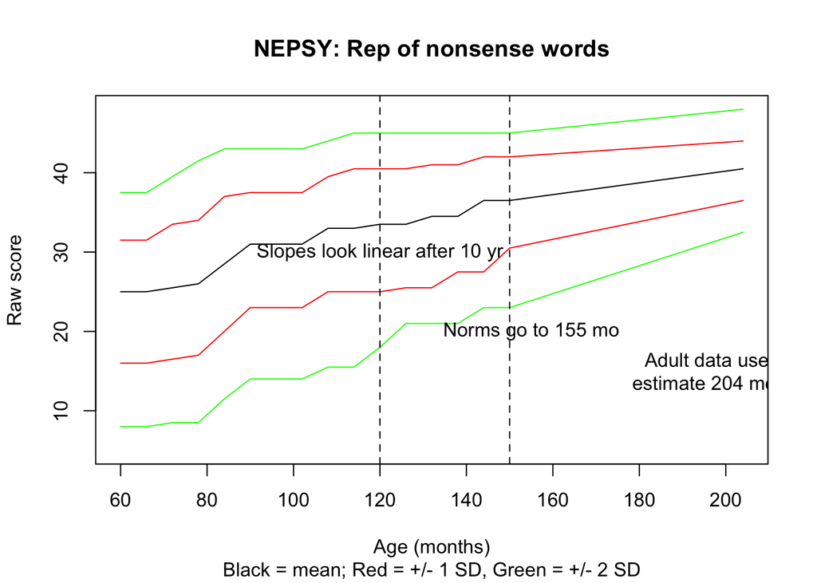

```r
myfile<-'~/Dropbox/Assessments/Nepsy for extrapolation.csv'
mydata<-read.csv(myfile) #myfile has raw score/scaled scores equivs for NEPSY and PhAB subtests
#Where adult data exist, the mean and scores for +/- 1 and 2 SD also added in final column
nwrp<-data.frame(mydata[1:5,])
myage<-seq(from=60,to=150,by=6) #age bands from norms
myage<-c(myage,204) #add an age band for adults; assign age of 17 yr because
#scores unlikely to improve further with age beyond then
myscore10<-nwrp[3,2:18] #mean raw scores at scaled score 10
myscore7<-nwrp[2,2:18]
myscore4<-nwrp[1,2:18]
myscore13<-nwrp[4,2:18]
myscore16<-nwrp[5,2:18]
plot(myage,myscore10,type="l",col="black",ylim=c(5,48),
     xlab="Age (months)", ylab="Raw score",
     main='NEPSY: Rep of nonsense words',sub='Black = mean; Red = +/- 1 SD, Green = +/- 2 SD' )
lines(myage,myscore7,col="red")
lines(myage,myscore4,col="green")
lines(myage,myscore13,col="red")
lines(myage,myscore16,col="green")
abline(v=150,lty=2)
abline(v=120,lty=2)
text(155,20,'Norms go to 155 mo')
text(200,15,'Adult data used to \nestimate 204 mo data')
text(120,30,'Slopes look linear after 10 yr')
```

The plots suggest a gradual upward trend in scores from 10 years to adulthood, and so we interpolated values between 155 and 204 months, using linear regression to estimate the three functions: one each for mean, +1 SD and -1 SD.

From this we can compute a norms table for the interpolated range. Below we just display the first few rows of this.

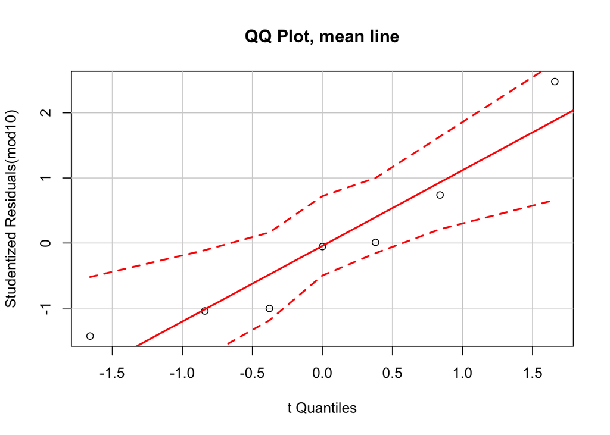

```r
#Linear regression used for all score levels; can then get interpolated values
#for teenagers
mod7<-lm(unlist(myscore7[11:17])~myage[11:17])
mod10<-lm(unlist(myscore10[11:17])~myage[11:17])
mod13<-lm(unlist(myscore13[11:17])~myage[11:17])
qqPlot(mod10, main="QQ Plot, mean line") #qq plot for studentized resid
```

```r
#Make a table of norms; use values from LM to estimate mean and +/- SD
teennorms<-matrix(NA,nrow=48,ncol=4)
myrow<-0
colnames(teennorms)<-c('months','mean','SDplus','SDminus')
for (mo in 156:203){ #ages 13 to 16;11
  myrow<-myrow+1
  teennorms[myrow,1]<-mo
  teennorms[myrow,2]<-mod10$coefficients[1]+mod10$coefficients[2]*mo
  teennorms[myrow,3]<-mod13$coefficients[1]+mod13$coefficients[2]*mo-teennorms[myrow,2]
  teennorms[myrow,4]<-mod7$coefficients[1]+mod7$coefficients[2]*mo-teennorms[myrow,2]
}
head(teennorms)
```

```
##      months     mean   SDplus   SDminus
## [1,]    156 36.60590 5.447052 -6.727620
## [2,]    157 36.69232 5.403839 -6.671124
## [3,]    158 36.77875 5.360626 -6.614629
## [4,]    159 36.86517 5.317413 -6.558133
## [5,]    160 36.95160 5.274199 -6.501638
## [6,]    161 37.03803 5.230986 -6.445142
```

In the next step, we read in raw data and use the new teennorms table to assign age-scaled scores to those aged 13 and over.

```r
#This code is shown for completeness: for this to work need to have the relevant
#data file in the working directory.
# alldata<-read.csv('SCT_data_forupdate_2017-09-15.csv',header=TRUE)
# mynrow<-nrow(alldata)
#
# for (i in 1:mynrow){
#   if(alldata$age_at_test[i]>156){
#     thisage<-as.integer(alldata$age_at_test[i])
#     thisscore<-alldata$nepsy_nonword_rep_raw[i]
#     teenrow<-thisage-155
#     mydiff<-thisscore-teennorms[teenrow,2] #obtained score minus mean
#     mysd<-teennorms[teenrow,3]
#     if(mydiff<0){mysd<- -teennorms[teenrow,4]}
#     # use upper or lower SD depending on whether above or below mean
#     alldata$nonword_rep_ss[i]<-as.integer(10+3*mydiff/mysd)
#     if(alldata$nonword_rep_ss[i]<1){alldata$nonword_rep_ss[i]<-1}
#   }
# }
# myvars<-c(1,2,212,213)
# checkdata<-alldata[,myvars]
# write.table(checkdata, "check_nwrp.txt", sep=",",row.names=FALSE)
# Table containing ID, age, raw and scaled nonword rep scores
```

### Sanity check on new scaled scores

We now plot all raw scores against age, showing the corresponding scaled scores in the plot. The results look coherent.

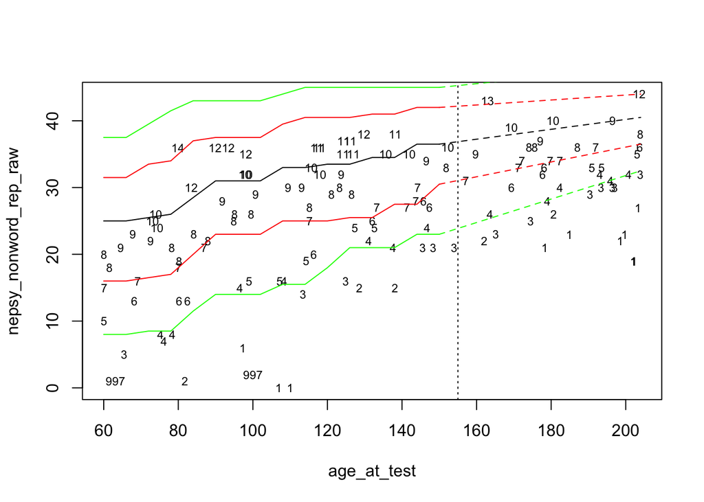

```r
nwrp.dat<-read.table("~/Dropbox/ERCadvanced/project SCT analysis/Extrapolated_norms/check_nwrp.txt",header=T, sep=",")
# Read in the data with original and new scaled scores
plot(nepsy_nonword_rep_raw ~ age_at_test, data=nwrp.dat, type='n')
text(nwrp.dat$age_at_test,nwrp.dat$nepsy_nonword_rep_raw,label=nwrp.dat$nonword_rep_ss,cex=.7)
lines(myage[1:16],myscore7[1:16],col="red")
lines(myage[1:16],myscore4[1:16],col="green")
lines(myage[1:16],myscore13[1:16],col="red")
lines(myage[1:16],myscore16[1:16],col="green")
lines(myage[1:16],myscore10[1:16],col="black")

lines(myage[16:17],myscore7[16:17],col="red",lty=2)
lines(myage[16:17],myscore4[16:17],col="green",lty=2)
lines(myage[16:17],myscore13[16:17],col="red",lty=2)
lines(myage[16:17],myscore16[16:17],col="green",lty=2)
lines(myage[16:17],myscore10[16:17],col="black",lty=2)
abline(v=155, lty=3)
```

### NEPSY Sentence Repetition

For sentence repetition we did not have any data on adults, so the only way to obtain norms beyond age 12;11 was to assume linear development after this age. To check whether this was reasonable, we followed the same procedure as for Repetition of Nonsense Words, plotting the raw scores for different scaled scores from the normative data.

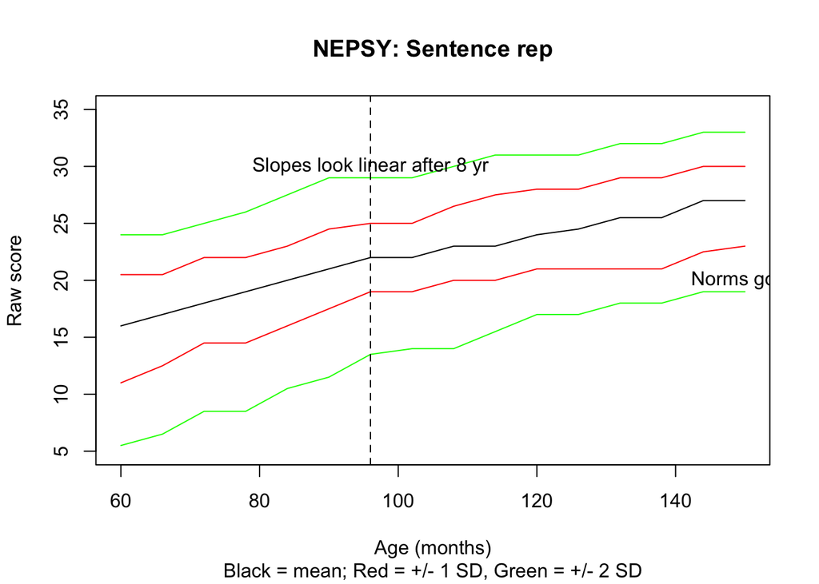

```r
myage<-seq(from=60,to=150,by=6) #age bands from norms
sentrep<-data.frame(mydata[8:12,1:17])
myscore10<-sentrep[3,2:17]
myscore7<-sentrep[2,2:17]
myscore4<-sentrep[1,2:17]
myscore13<-sentrep[4,2:17]
myscore16<-sentrep[5,2:17]
plot(myage,myscore10,type="l",col="black",ylim=c(5,35),
     xlab="Age (months)", ylab="Raw score",
     main='NEPSY: Sentence rep',sub='Black = mean; Red = +/- 1 SD, Green = +/- 2 SD' )
lines(myage,myscore7,col="red")
lines(myage,myscore4,col="green")
lines(myage,myscore13,col="red")
lines(myage,myscore16,col="green")

abline(v=96,lty=2)
text(155,20,'Norms go to 155 mo')
text(96,30,'Slopes look linear after 8 yr')
```

On visual inspection, development with age looks linear, suggestion extrapolation is reasonable. We therefore adopt the same approach as before, using linear regression to derive norms from normative data from 8;0 to 12;11

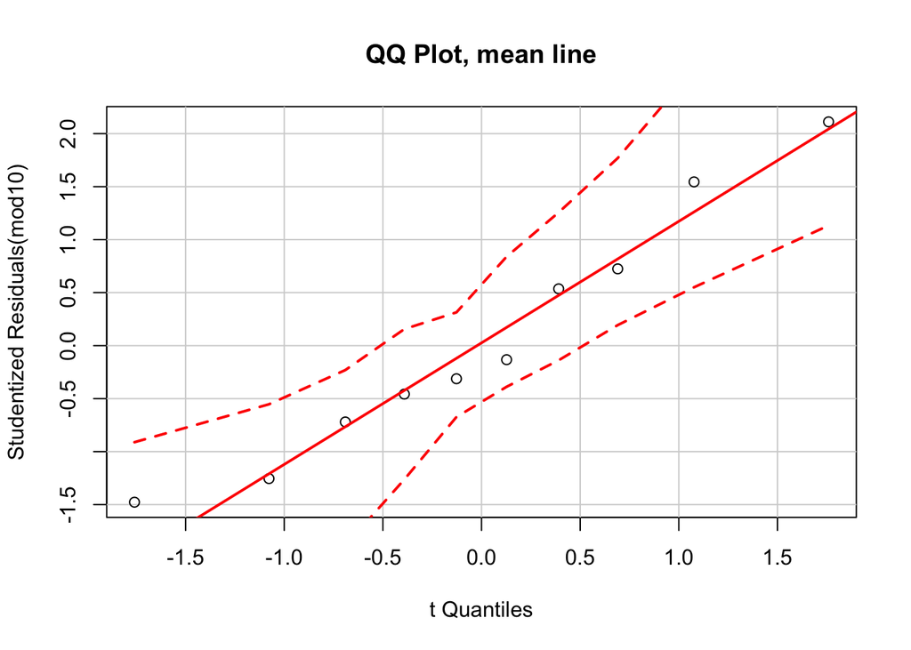

```r
#Linear regression based on norms from 8 to 12;11
mod7<-lm(unlist(myscore7[7:16])~myage[7:16])
mod10<-lm(unlist(myscore10[7:16])~myage[7:16])
mod13<-lm(unlist(myscore13[7:16])~myage[7:16])
qqPlot(mod10, main="QQ Plot, mean line") #qq plot for studentized resid
```

```r
#Make a table of norms; use values from LM to estimate mean and +/- SD
teennorms<-matrix(NA,nrow=48,ncol=4)
myrow<-0
colnames(teennorms)<-c('months','mean','SDplus','SDminus')
for (mo in 156:203){ #ages 13 to 16;11
  myrow<-myrow+1
  teennorms[myrow,1]<-mo
  teennorms[myrow,2]<-mod10$coefficients[1]+mod10$coefficients[2]*mo
  teennorms[myrow,3]<-mod13$coefficients[1]+mod13$coefficients[2]*mo-teennorms[myrow,2]
  teennorms[myrow,4]<-mod7$coefficients[1]+mod7$coefficients[2]*mo-teennorms[myrow,2]
}
head(teennorms)
```

```
##      months     mean   SDplus   SDminus
## [1,]    156 27.70000 3.333333 -4.666667
## [2,]    157 27.80152 3.329798 -4.698990
## [3,]    158 27.90303 3.326263 -4.731313
## [4,]    159 28.00455 3.322727 -4.763636
## [5,]    160 28.10606 3.319192 -4.795960
## [6,]    161 28.20758 3.315657 -4.828283
```

Teennorms shows first few rows of estimated means/SDs for conversion. This is then used with our main datafile to convert raw scores into scaled. Commented out here as won’t work in markdown without the file.

```r
# for (i in 1:mynrow){
#   if(alldata$age_at_test[i]>156){
#     thisage<-as.integer(alldata$age_at_test[i])
#     thisscore<-alldata$nepsy_sent_rep_raw[i]
#     teenrow<-thisage-155
#     mydiff<-thisscore-teennorms[teenrow,2]
#     mysd<-teennorms[teenrow,3]
#     if(mydiff<0){mysd<- -teennorms[teenrow,4]}
#     alldata$sent_rep_ss[i]<-as.integer(10+3*mydiff/mysd)
#     if(alldata$sent_rep_ss[i]<1){alldata$sent_rep_ss[i]<-1}
#   }
# }
# myvars<-c(1,2,175,176)
# checkdata<-alldata[,myvars]
# write.table(checkdata, "check_sentrep.txt", sep=",",row.names=FALSE)
```

Now plot raw scores vs age, with scaled score as number in plot. These look reasonable. In particular, note that where very low scaled scores are obtained, these would be similarly low if compared vs oldest age band with norms (which would be an alternative way of getting a scaled score that assumed no age improvement after 12 yr, so would be rather generous).

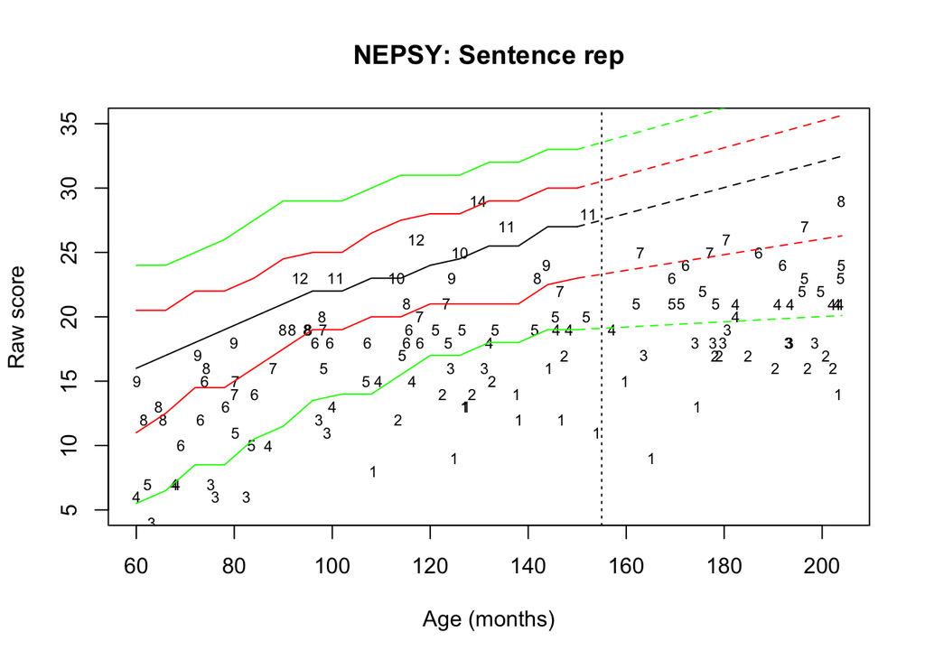

```r
sentrep.dat<-read.table("~/Dropbox/ERCadvanced/project SCT analysis/Extrapolated_norms/check_sentrep.txt",header=T, sep=",")
# Read in the data with original and new scaled scores
plot(nepsy_sent_rep_raw ~ age_at_test, data=sentrep.dat, type='n',
     ylim=c(5,35),
     xlab="Age (months)", ylab="Raw score",
     main='NEPSY: Sentence rep')
text(sentrep.dat$age_at_test,sentrep.dat$nepsy_sent_rep_raw,label=sentrep.dat$sent_rep_ss,cex=.7)
lines(myage[1:16],myscore7[1:16],col="red")
lines(myage[1:16],myscore4[1:16],col="green")
lines(myage[1:16],myscore13[1:16],col="red")
lines(myage[1:16],myscore16[1:16],col="green")
lines(myage[1:16],myscore10[1:16],col="black")

#Need to create predicted values for last point in series
myage[17]<-204
myscore4[17]<-teennorms[48,2]+2*teennorms[48,4]
myscore7[17]<-teennorms[48,2]+teennorms[48,4]
myscore10[17]<-teennorms[48,2]
myscore13[17]<-teennorms[48,2]+teennorms[48,3]
myscore16[17]<-teennorms[48,2]+2*teennorms[48,3]

#Extrapolated portion shown with dotted lines, lty=2
lines(myage[16:17],myscore7[16:17],col="red",lty=2)
lines(myage[16:17],myscore4[16:17],col="green",lty=2)
lines(myage[16:17],myscore13[16:17],col="red",lty=2)
lines(myage[16:17],myscore16[16:17],col="green",lty=2)
lines(myage[16:17],myscore10[16:17],col="black",lty=2)

abline(v=155, lty=3)
```

### NEPSY Oromotor sequences

This is not ideal for entering into statistical analyses, and so for this subtest, the norms were used to identify 25th and 75th centiles for all ages, with the middle point between these values treated as the mean.

The statistical approach is then similar to Nonword Repetition, except that rather than transforming scores on the basis of SD units, we take into account that the 25th and 75th centiles correspond to z-scores of +/- .675, and then estimate the raw scores that correspond to age-scaled scores in units of .33 SD (i.e. scaled scores of 1, 2, 3 etc)

As before, adults are assigned age of 204 mo for the regression estimates. Maximum score on this subtest is 70

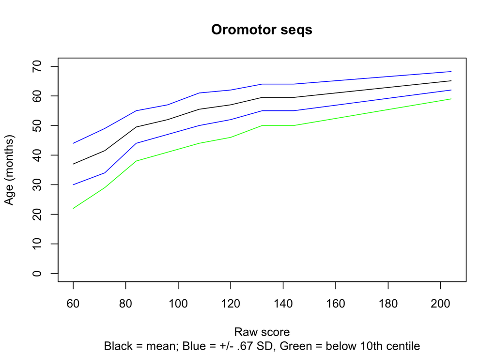

```r
orodata<-data.frame(mydata[15:18,4:12])
colnames(orodata)<-c(5,6,7,8,9,10,11,12,17)
myage<-seq(from=60,to=150,by=12)
myage<-c(myage,204)

myscoreneg<-orodata[3,]
myscorepos<-orodata[1,]
myscoremean<-orodata[2,]
myscorelow<-orodata[4,]

plot(myage,myscoremean,type="l",col="black",ylim=c(0,70),main='Oromotor seqs', xlab='Raw score',ylab='Age (months)',sub='Black = mean; Blue = +/- .67 SD, Green = below 10th centile' )
lines(myage,myscoreneg,col="blue")
lines(myage,myscorepos,col="blue")
lines(myage,myscorelow,col="green")
```

We need to consider the whole range from 5 yr to 17 yr, and the function looks nonlinear, so here we use log age (yr) as predictor of raw score.

This gives a better fit than a simple linear model with age as predictor (Rsquared values are all greater than .9).

```r
ageforfit<-log(myage/12)
mod7<-lm(unlist(myscoreneg)~ageforfit)
mod10<-lm(unlist(myscoremean)~ageforfit)
mod13<-lm(unlist(myscorepos)~ageforfit)
summary(mod10)
```

```
##
## Call:
## lm(formula = unlist(myscoremean) ~ ageforfit)
##
## Residuals:
##    Min     1Q Median     3Q    Max
## -3.104 -2.289  1.223  1.487  2.196
##
## Coefficients:
##             Estimate Std. Error t value Pr(>|t|)
## (Intercept)    1.743      4.765   0.366    0.725
## ageforfit     23.466      2.155  10.889 1.22e-05 ***
## ---
## Signif. codes:  0 '***' 0.001 '**' 0.01 '*' 0.05 '.' 0.1 ' ' 1
##
## Residual standard error: 2.284 on 7 degrees of freedom
## Multiple R-squared:  0.9443, Adjusted R-squared:  0.9363
## F-statistic: 118.6 on 1 and 7 DF,  p-value: 1.217e-05
```

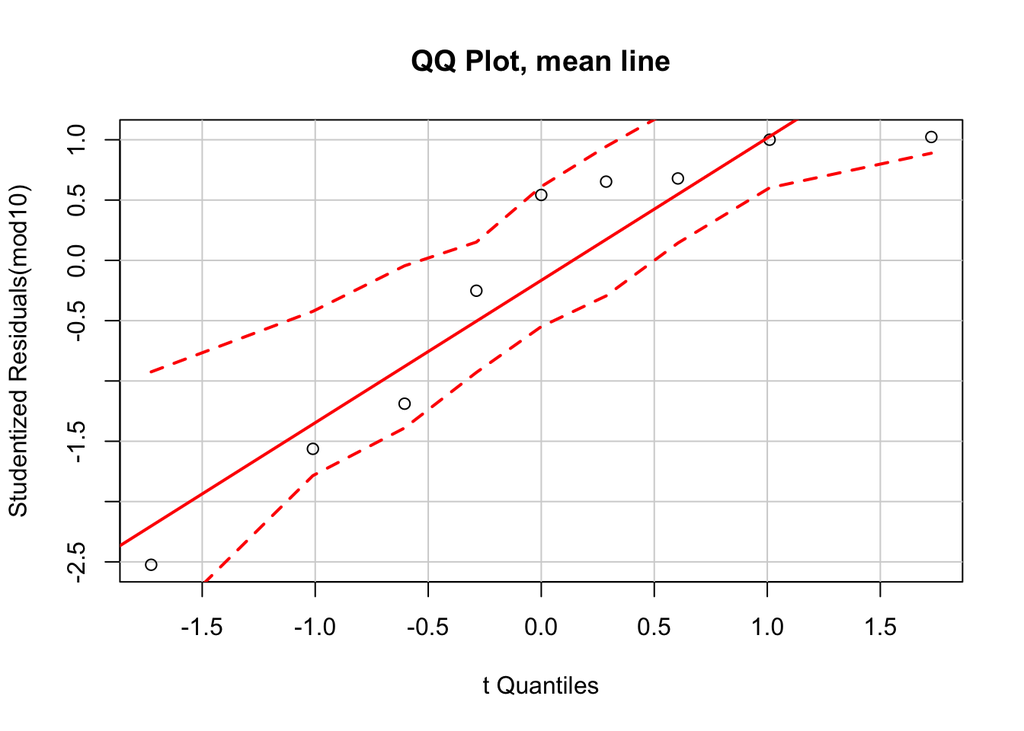

```r
qqPlot(mod10, main="QQ Plot, mean line") #qq plot for studentized resid
```

```r
#NB To keep commands simple, we are reusing the variable names as for previous tests, but note that the values for mod7 and mod13 are here equivalent to 25 and 75th percentile, not SDs

#----------------------------------------------------------
#Use regression equation to make norms  in file oross
#NB this time, as they are no scaled scores in the manual, we will create them

#----------------------------------------------------------
oross<-matrix(NA,nrow=144,ncol=4)
myrow<-0
colnames(oross)<-c('logage(yr)','mean','plus25','minus25')
#Note that this time the boundaries are +/- 25th/75th centile and not in SDs
for (mo in 60:203){ #ages 5 to 16
  myrow<-myrow+1
  oross[myrow,1]<-mo
  mylogage<-log(mo/12)
  oross[myrow,2]<-mod10$coefficients[1]+mod10$coefficients[2]*mylogage
  oross[myrow,3]<-mod13$coefficients[1]+mod13$coefficients[2]*mylogage-oross[myrow,2]
  oross[myrow,4]<-mod7$coefficients[1]+mod7$coefficients[2]*mylogage-oross[myrow,2]
}
head(oross)
```

```
##      logage(yr)     mean   plus25   minus25
## [1,]         60 39.51100 7.185292 -7.185292
## [2,]         61 39.89888 7.130671 -7.130671
## [3,]         62 40.28046 7.076939 -7.076939
## [4,]         63 40.65593 7.024066 -7.024066
## [5,]         64 41.02548 6.972026 -6.972026
## [6,]         65 41.38931 6.920792 -6.920792
```

This next section is commented out, as it requires the raw data file.

```r
# colnames(alldata)[196]<-'oromotor_ss'
# for (i in 1:mynrow){
#
#     thisage<-as.integer(alldata$age_at_test[i])
#     thisscore<-alldata$nepsy_oromotor_seq_raw[i]
#     if(is.na(thisscore)){thisscore<-999}
#     thisrow<-thisage-59
#     mydiff<-thisscore-oross[thisrow,2]
#     mysd<-oross[thisrow,3]
#     if(mydiff<0){mysd<- -oross[thisrow,4]}
#     mysd<-(1/.675)*mysd #
#     alldata$oromotor_ss[i]<-as.integer(10+3*mydiff/mysd)
#     if(alldata$oromotor_ss[i]<1){alldata$oromotor_ss[i]<-1}
#     if(alldata$oromotor_ss[i]>19){alldata$oromotor_ss[i]<-19}
#     if(thisscore>900){alldata$oromotor_ss[i]<-alldata$nepsy_oromotor_seq_raw[i]}
# }
# myvars<-c(1,2,195,196)
# checkdata<-alldata[,myvars]
# checkdata<-cbind(checkdata,mytemp)
# write.table(checkdata, "check_oromotor.txt", sep=",",row.names=FALSE)
```

We have created check_oromotor.txt from the raw data, and now can inspect the plot of raw score by age, with scaled scores.

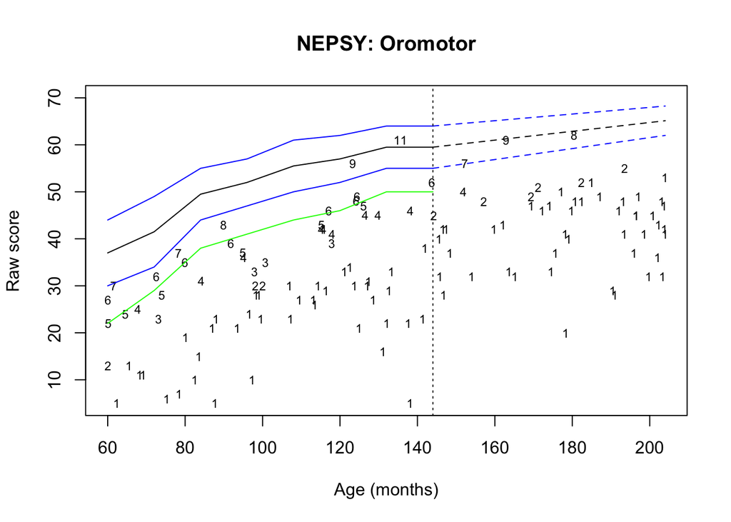

```r
oromotor.dat<-read.table("~/Dropbox/ERCadvanced/project SCT analysis/Extrapolated_norms/check_oromotor.txt",header=T, sep=",")
# Read in the data with new scaled scores
plot(nepsy_oromotor_seq_raw ~ age_at_test, data=oromotor.dat, type='n',
     ylim=c(5,70),
     xlab="Age (months)", ylab="Raw score",
     main='NEPSY: Oromotor')
text(oromotor.dat$age_at_test,oromotor.dat$nepsy_oromotor_seq_raw,
     label=oromotor.dat$oromotor_ss,cex=.7)

lines(myage[1:8],myscoreneg[1:8],col="blue")
lines(myage[1:8],myscorepos[1:8],col="blue")
lines(myage[1:8],myscoremean[1:8],col="black")
lines(myage[1:8],myscorelow[1:8],col="green")

#Extrapolated portion shown with dotted lines
lines(myage[8:9],myscoreneg[8:9],col="blue",lty=2)
lines(myage[8:9],myscorepos[8:9],col="blue",lty=2)
lines(myage[8:9],myscoremean[8:9],col="black",lty=2)

abline(v=144, lty=3)
```

The plot shows a high level of very poor scores. Note that these are now age-scaled scores with mean 10 and SD 3, rather than the 5-point scale from NEPSY norms.

Although the low scores might suggest something wrong with the transformation, note that these low scores are seen throughout the age range, including the cases aged below 12, who can be evaluated against the normative data (black line shows mean, and blue shows 25th and 75th centiles). The v low scores seem a true reflection of the poor performance on this subtest. This also agreed with observation of children doing the test - many found this subtest remarkably difficult.

### PhAB rapid naming subtests

The PhAB has norms for ages 6;0 to 14;11, so the published tables did not cover the 11 children aged below 6 years or the 27 children aged 15;0 and above. For those aged 6;0 to 14;11 norm tables are provided to convert raw (time) scores to scaled scores with mean 100 and SD 15.

We did not have adult data for these subtests.

We considered the same approach as for the NEPSY subtests, taking the raw scores corresponding to scaled scores that were -2 SD, -1 SD, mean, +1 SD and +2 SD (i.e. scaled scores of 70, 85, 100, 115 and 130).

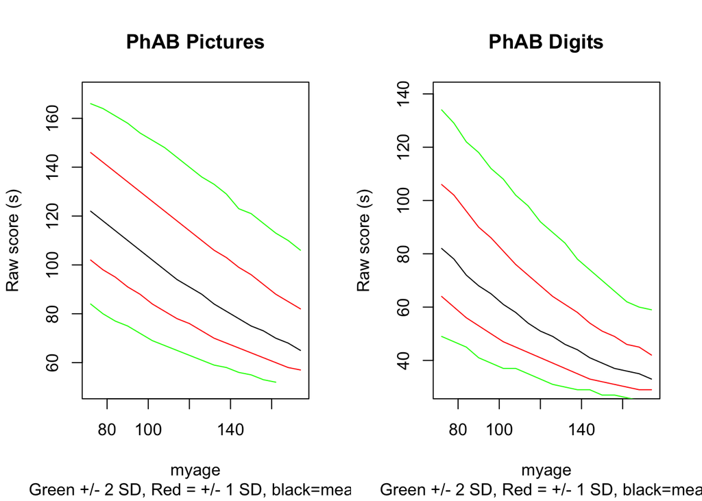

```r
par(mfrow=c(1,2)) #side by side plots
for (ph in 1:2){ #2 subtests in turn
  mytitle<-'PhAB Pictures'
  ylims<-c(50,170)
phabdata<-mydata[21:25,2:19]
if (ph>1 ){phabdata<-mydata[28:32,2:19];
mytitle<-'PhAB Digits'
ylims<-c(30,140)}
myage<-seq(from=72,to=174,by=6)
myscore100<-phabdata[3,1:18]
myscore70<-phabdata[1,1:18]
myscore85<-phabdata[2,1:18]
myscore115<-phabdata[4,1:18]
myscore130<-phabdata[5,1:18]
plot(myage,myscore100,type="l",col="black",ylim=ylims,main=mytitle,
     sub='Green +/- 2 SD, Red = +/- 1 SD, black=mean',ylab='Raw score (s)')
lines(myage,myscore85,col="red")
lines(myage,myscore70,col="green")
lines(myage,myscore115,col="red")
lines(myage,myscore130,col="green")
if(ph==1){myscore100p<-myscore100; myscore70p<-myscore70; myscore130p<-myscore130;
myscore115p<-myscore115; myscore85p<-myscore85}#need these for plotting later
}
```

The plots reveal a problem, that is especially marked for the digits test, with a floor effect constraining the range of scores in older children. We experimented with various approaches to estimation, but concluded that the least bad option would be to use norms for the oldest children (14;06-14;11) for the 15- and 16-year-olds.

```r
#Values in myvals are entered manually from test manual data children
#Select rows for children aged over 14;11
#myrows<-which(alldata$age_at_test>179.999)
myrows<-c(6, 7, 9, 12, 13, 16, 18, 23, 29, 33, 43, 45, 46, 51, 54, 66, 68, 70, 74, 81, 88, 92, 94, 106, 133, 138, 142) #alldata not available so give actual values here
#Values for picture naming
myvals<-c(109, 88, 87, 88, 78, 99, 88, 83, 96, 94, 73, 102, 92, 90, 111, 100, 69, 99, 80, 77, 81, 99, 88, 77, 79, 87, 69)
#alldata[myrows,241]<-myvals

# Values for digit naming
myvals<-c(89,72,82,78,101,107,90,81,99,73,69,91,83,90,131,109,74,84,72,77,93,94,69,75,81,95,77)
#alldata[myrows,243]<-myvals
# myvars<-c(1,2,240:243)
# checkdata<-alldata[,myvars]
# write.table(checkdata, "check_phab.txt", sep=",",row.names=FALSE)
```

Now we can read in the data and see whether it looks orderly, or whether older children appear to have scores overestimated.

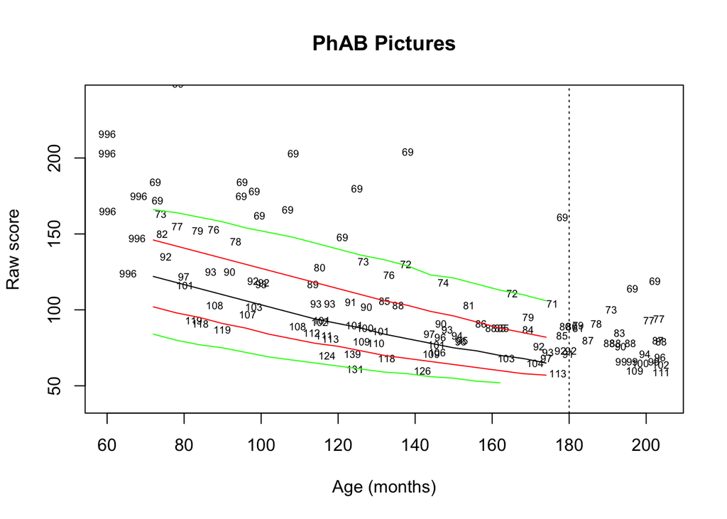

```r
phab.dat<-read.table("~/Dropbox/ERCadvanced/project SCT analysis/Extrapolated_norms/check_phab.txt",header=T, sep=",")
w<-which(phab.dat[,3]>900)
phab.dat[w,3]<-NA
w<-which(phab.dat[,5]>900)
phab.dat[w,5]<-NA


# Plot the data with new scaled scores
plot(phab_pics_raw ~ age_at_test, data=phab.dat, type='n',
     ylim=c(40,240),
     xlab="Age (months)", ylab="Raw score",
     main='PhAB Pictures')
text(phab.dat$age_at_test,phab.dat$phab_pics_raw,
     label=phab.dat$phab_pic_ss,cex=.6)

lines(myage,myscore85p,col="red")
lines(myage,myscore115p,col="red")
lines(myage,myscore100p,col="black")
lines(myage,myscore70p,col="green")
lines(myage,myscore130p,col="green")

abline(v=180, lty=3)
```

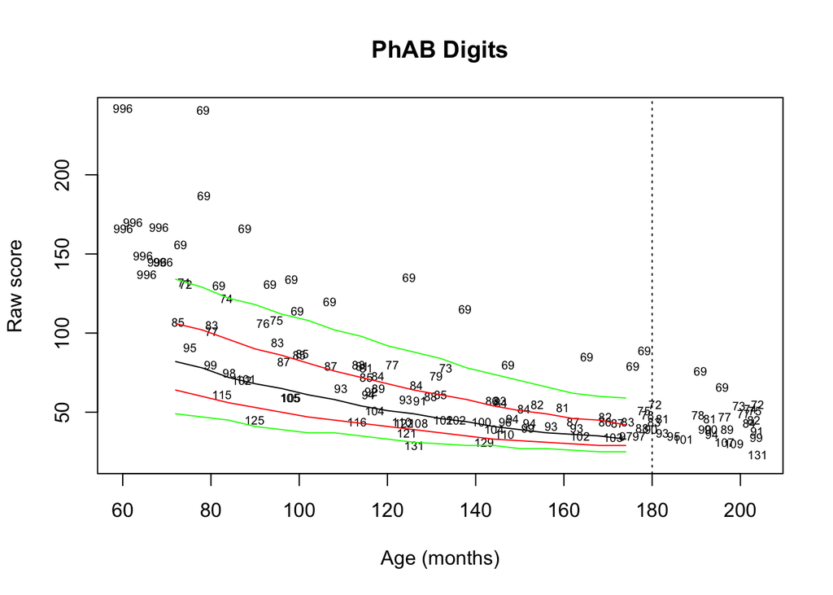

```r
plot(phab_digits_raw ~ age_at_test, data=phab.dat, type='n',
     ylim=c(20,240),
     xlab="Age (months)", ylab="Raw score",
     main='PhAB Digits')
text(phab.dat$age_at_test,phab.dat$phab_digits_raw,
     label=phab.dat$phab_digit_ss,cex=.6)

lines(myage,myscore85,col="red")
lines(myage,myscore115,col="red")
lines(myage,myscore100,col="black")
lines(myage,myscore70,col="green")
lines(myage,myscore130,col="green")

abline(v=180, lty=3)
```

### Neale Analysis of Reading Ability

The NARA has norms up to age 12;11, with age scaled scores (mean 100 and SD 15) given for 3-monthly age bands. It is evident from the norms that ceiling effects start to have an impact at older ages - e.g. the highest possible accuracy score at age 12;09 is 123.

To consider whether we can nevertheless include data from children aged 13 years and over, we first plotted the obtained data in relation to test norms.

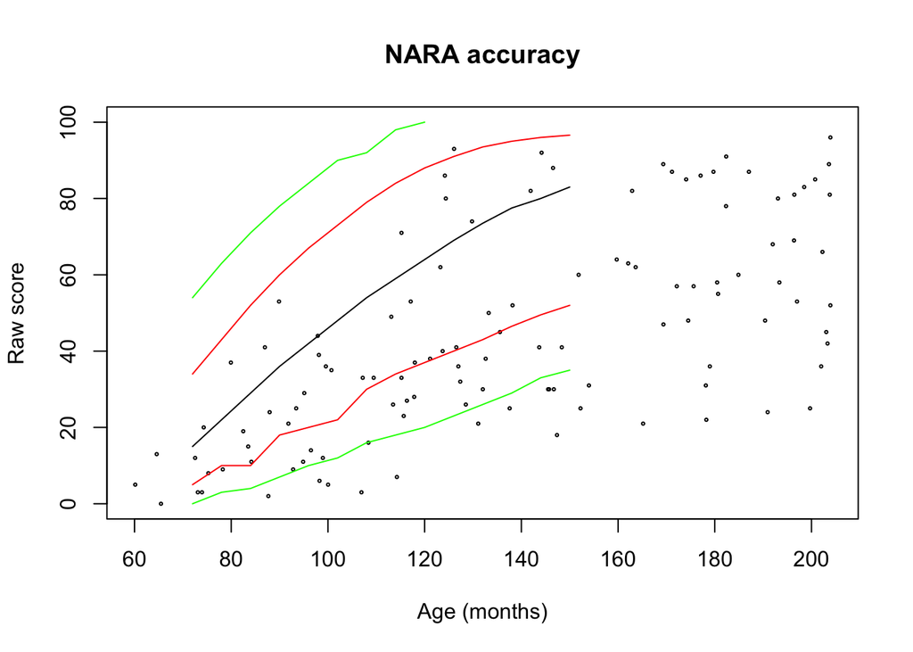

```r
nara.dat<-read.table("~/Dropbox/ERCadvanced/project SCT analysis/Extrapolated_norms/check_nara.txt",header=T, sep=",")
#NARA-accuracy
nara.acc<-mydata[35:39,2:15]
myage<-seq(from=72,to=150,by=6)
myscore100<-nara.acc[3,1:14]
myscore70<-nara.acc[1,1:14]
myscore85<-nara.acc[2,1:14]
myscore115<-nara.acc[4,1:14]
myscore130<-nara.acc[5,1:14]
plot(nara_acc ~ age_at_test, data=nara.dat,type='p',cex=.3,
     ylim=c(0,100),
     xlab="Age (months)", ylab="Raw score",
     main='NARA accuracy')
lines(myage,myscore100,col="black")
lines(myage,myscore85,col="red")
lines(myage,myscore70,col="green")
lines(myage,myscore115,col="red")
lines(myage,myscore130,col="green")
```

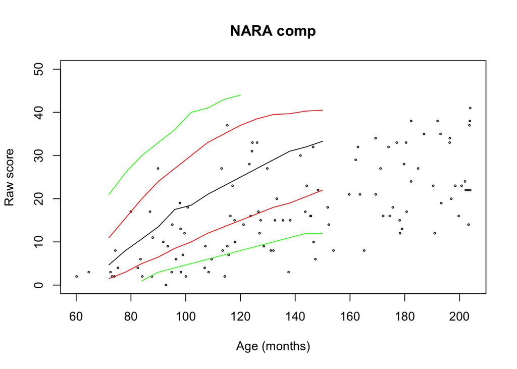

```r
#NARA-comp
nara.comp<-mydata[42:46,2:15]
myage<-seq(from=72,to=150,by=6)
myscore100<-nara.comp[3,1:14]
myscore70<-nara.comp[1,1:14]
myscore85<-nara.comp[2,1:14]
myscore115<-nara.comp[4,1:14]
myscore130<-nara.comp[5,1:14]
plot(nara_comp ~ age_at_test, data=nara.dat,type='p',cex=.3,
     ylim=c(0,50),
     xlab="Age (months)", ylab="Raw score",
     main='NARA comp')
lines(myage,myscore100,col="black")
lines(myage,myscore85,col="red")
lines(myage,myscore70,col="green")
lines(myage,myscore115,col="red")
lines(myage,myscore130,col="green")
```

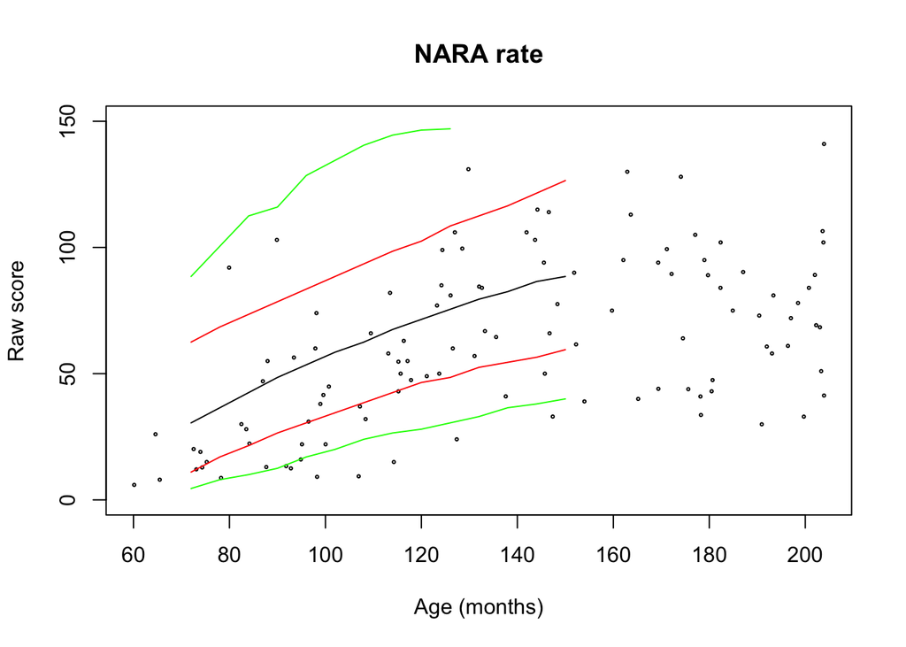

```r
#NARA-rate
nara.rate<-mydata[49:53,2:15]
myage<-seq(from=72,to=150,by=6)
myscore100<-nara.rate[3,1:14]
myscore70<-nara.rate[1,1:14]
myscore85<-nara.rate[2,1:14]
myscore115<-nara.rate[4,1:14]
myscore130<-nara.rate[5,1:14]
plot(nara_rate ~ age_at_test, data=nara.dat,type='p',cex=.3,
     ylim=c(0,150),
     xlab="Age (months)", ylab="Raw score",
     main='NARA rate')
lines(myage,myscore100,col="black")
lines(myage,myscore85,col="red")
lines(myage,myscore70,col="green")
lines(myage,myscore115,col="red")
lines(myage,myscore130,col="green")
```

Inspection of these distributions suggests that it would be reasonable to use the norms for the oldest age band (12;09 to 12;11) to obtain scaled scores for the older children. In general, few children are above average relative to this criterion, and many are in impaired range. This approach may underestimate severity of impairment, but it will give indication of which children have difficulties. This was done by direct lookup from manual.

```r
# Values then added to this table manually using norms for 12;09 to 12;11
# Shown here for completeness, but done in separate script.
myrow<-c(4, 6, 7, 9, 12, 13, 14, 16, 17, 18, 23, 25, 29, 33, 43, 45, 46, 47, 51, 52, 54, 57, 63, 66, 68, 70, 74, 78, 81, 86, 87, 88, 92, 94, 101, 103, 106, 108, 109, 110, 115, 124, 133, 134, 138, 142)
myacc<-c(69, 85, 84, 81, 82, 102, 997, 92, 102, 91, 98, 87, 104, 69, 69, 98, 87, 69, 87, 70, 111, 100, 89, 99, 90, 70, 86, 82, 100, 89, 69, 106, 997, 997, 88, 102, 78, 104, 81, 87, 98, 999, 96, 100, 88, 98)
mycomp<-c(69, 81, 84, 84, 86, 101, 999, 98, 90, 108, 101, 79, 105, 76, 69, 108, 98, 75, 80, 70, 117, 98, 93, 86, 84, 87, 77, 76, 86, 83, 69, 108, 997, 997, 83, 91, 73, 100, 83, 76, 97, 999, 87, 97, 90, 100)
myrate<-c(69, 91, 70, 89, 91, 100, 999, 85, 103, 85, 84, 72, 106, 69, 69, 104, 72, 70, 95, 102, 126, 105, 102, 94, 89, 99, 76, 87, 97, 92, 70, 104, 997, 997, 108, 99, 79, 102, 74, 99, 116, 999, 97, 115, 92, 997)
#nara.update<-cbind(alldata[myrow,1],myacc,mycomp,myrate)
#colnames(nara.update)<-c("record_id", "nara_acc_ss" , "nara_comp_ss","nara_rate_ss")
#write.table(nara.update, "nara_update_for_redcap.txt", sep=",",row.names=FALSE)
```

Replot with the updated values shown

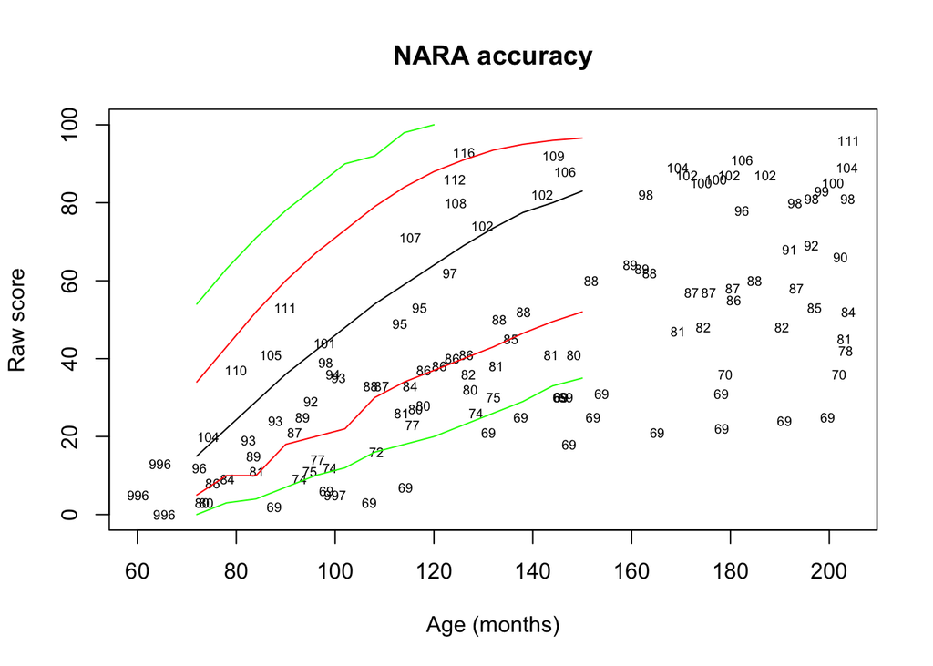

```r
nara.dat<-read.table("~/Dropbox/ERCadvanced/project SCT analysis/Extrapolated_norms/check_nara.txt",header=T, sep=",")
#This file was created using the myrow, myacc, mycomp, myrate as above

#NARA-accuracy
nara.acc<-mydata[35:39,2:15]
myage<-seq(from=72,to=150,by=6)
myscore100<-nara.acc[3,1:14]
myscore70<-nara.acc[1,1:14]
myscore85<-nara.acc[2,1:14]
myscore115<-nara.acc[4,1:14]
myscore130<-nara.acc[5,1:14]
plot(nara_acc ~ age_at_test, data=nara.dat,type='n',
     ylim=c(0,100),
     xlab="Age (months)", ylab="Raw score",
     main='NARA accuracy')
text(nara.dat$age_at_test,nara.dat$nara_acc,
     label=nara.dat$nara_acc_ss,cex=.6)
lines(myage,myscore100,col="black")
lines(myage,myscore85,col="red")
lines(myage,myscore70,col="green")
lines(myage,myscore115,col="red")
lines(myage,myscore130,col="green")
```

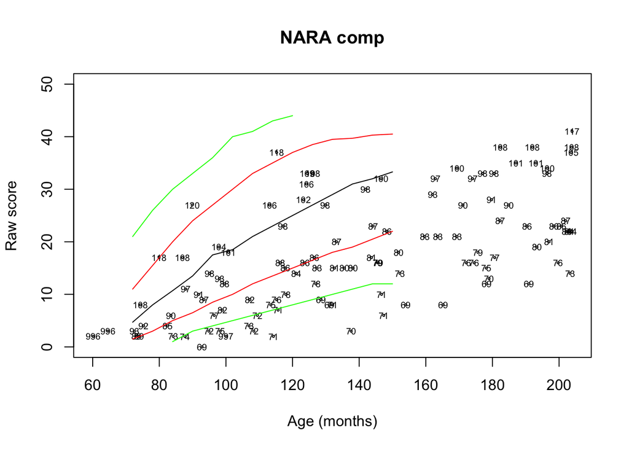

```r
#NARA-comp
nara.comp<-mydata[42:46,2:15]
myage<-seq(from=72,to=150,by=6)
myscore100<-nara.comp[3,1:14]
myscore70<-nara.comp[1,1:14]
myscore85<-nara.comp[2,1:14]
myscore115<-nara.comp[4,1:14]
myscore130<-nara.comp[5,1:14]
plot(nara_comp ~ age_at_test, data=nara.dat,type='p',cex=.3,
     ylim=c(0,50),
     xlab="Age (months)", ylab="Raw score",
     main='NARA comp')
text(nara.dat$age_at_test,nara.dat$nara_comp,
     label=nara.dat$nara_comp_ss,cex=.6)
lines(myage,myscore100,col="black")
lines(myage,myscore85,col="red")
lines(myage,myscore70,col="green")
lines(myage,myscore115,col="red")
lines(myage,myscore130,col="green")
```

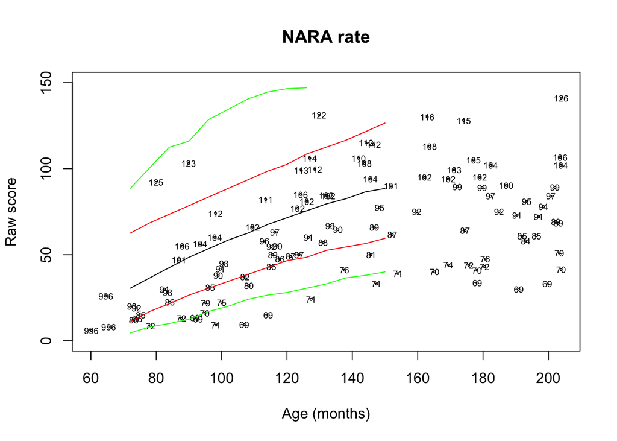

```r
#NARA-rate
nara.rate<-mydata[49:53,2:15]
myage<-seq(from=72,to=150,by=6)
myscore100<-nara.rate[3,1:14]
myscore70<-nara.rate[1,1:14]
myscore85<-nara.rate[2,1:14]
myscore115<-nara.rate[4,1:14]
myscore130<-nara.rate[5,1:14]
plot(nara_rate ~ age_at_test, data=nara.dat,type='p',cex=.3,
     ylim=c(0,150),
     xlab="Age (months)", ylab="Raw score",
     main='NARA rate')
text(nara.dat$age_at_test,nara.dat$nara_rate,
     label=nara.dat$nara_rate_ss,cex=.6)
lines(myage,myscore100,col="black")
lines(myage,myscore85,col="red")
lines(myage,myscore70,col="green")
lines(myage,myscore115,col="red")
lines(myage,myscore130,col="green")
```